# Lab template

STATS 369

*It is good practice to have all your general set up at the start of your document. Imagine this is the beginning of a new Rmd. This is where I would set any general chunk options, as well as where I would load my libraries. If I realise I need additional libraries later, I would come back here and add them.*

*Notes from me are in italics.*

```r
# Set code to show
knitr::opts_chunk$set(echo = TRUE)

# Load libraries
library(tidyverse)

library(glue) # awesome package that we don't have time to talk about
library(lubridate) # helps make dates much easier

library(TMDb) # provides access to the API
library(keyring) # for storing our API key

library(polite)
```

## Task 1

*Use headings to organise your submission and make it easy for your marker to find your answers*

```r
# Bow
bow_imdb <- bow("https://www.imdb.com/search/keyword/?keywords=christmas&ref_=kw_nxt&sort=moviemeter,asc&mode=detail&page=2&title_type=movie")
bow_imdb
```

```
## <polite session> https://www.imdb.com/search/keyword/?keywords=christmas&ref_=kw_nxt&sort=moviemeter,asc&mode=detail&page=2&title_type=movie
##     User-agent: polite R package
##     robots.txt: 34 rules are defined for 2 bots
##    Crawl delay: 5 sec
##   The path is scrapable for this user-agent
```

## Task 2

No, we can’t ethically scrape IMDB without their permission. Despite the polite message saying the path is able to be scraped, we should not scrape IMDB because in their T’s and C’s they explicitly say that “You may not use data mining, robots, screen scraping, or similar data gathering and extraction tools on this site, except with our express written consent as noted below.” (from https://www.imdb.com/conditions). As we do not have explicit written permission, it is unethical to scrape IMDB.

```r
# Sign in
# key_set("TMDB_API")
# b58beee5ecf98a1792d3d9fb24a5c1b1
```

## Task 3

```r
genres = read_csv("genres.csv")
head(genres)
```

```
## # A tibble: 1 x 19
##   `28`   `12`    `16`  `35`  `80`  `99`  `18`  `10751` `14`  `36`  `27`  `10402`
##   <chr>  <chr>   <chr> <chr> <chr> <chr> <chr> <chr>   <chr> <chr> <chr> <chr>
## 1 Action Advent~ Anim~ Come~ Crime Docu~ Drama Family  Fant~ Hist~ Horr~ Music
## # ... with 7 more variables: `9648` <chr>, `10749` <chr>, `878` <chr>,
## #   `10770` <chr>, `53` <chr>, `10752` <chr>, `37` <chr>
```

This dataset is not tidy.

Making it tidy:

```r
tidy_genres = pivot_longer(genres, cols = "28":"37", names_to = "number", values_to = "genre")
head(tidy_genres)
```

```
## # A tibble: 6 x 2
##   number genre
##   <chr>  <chr>
## 1 28     Action
## 2 12     Adventure
## 3 16     Animation
## 4 35     Comedy
## 5 80     Crime
## 6 99     Documentary
```

```r
# From Liza
search_keyword <- function(api_key, query, page=1){
    if(page<1 || page>1000){
        stop("page must be a number between 1 and 1000")
    }
    l <- list(page=page)
    l <- l[!is.na(l)]

    params <- paste("&", names(l), "=",l, sep="", collapse="")
    url <- fromJSON(GET(URLencode(url<-
                                    paste(                          "http://api.themoviedb.org/3/search/keyword?api_key=",
                                      api_key,
                                      "&query=",
                                      query,
                                      params,
                                      sep = ""
                                    )))$url)

    return(url)
}
```

```r
# a function that runs this for command for any given page
one_page <- function(x) search_keyword(key_get("TMDB_API"), query = "christmas", page = x)

# a vector of the pages, from 1 to the max page for this search
pages <- 1:one_page(1)$total_pages

# now use map_dfr (map specifcally for returning data frames) instead of a for loop
christmas_keywords <- map_dfr(pages, function(x) one_page(x)$results)
christmas_keywords
```

```
##        id                               name
## 1  207317                          christmas
## 2  193048                   christmas spirit
## 3  236216          nordic christmas calendar
## 4  196018                  christmas reunion
## 5  254789                     christmas food
## 6  255088                  christmas special
## 7  170496              christmas tree dealer
## 8  172742                   christmas lights
## 9  228081                   christmas parade
## 10 228415                    christmas bonus
## 11 188345                     christmas card
## 12 269672                  christmas pageant
## 13 270896                  christmas pudding
## 14   1441                    christmas party
```

[output cut: 33 more lines]

## Task 4: Find a set of key word you’re interested in

```r
alien_page <- function(x) search_keyword(key_get("TMDB_API"), query = "alien", page = x)
alien_pages <- 1:alien_page(1)$total_pages
alien_keywords <- map_dfr(alien_pages, function(x) alien_page(x)$results)
head(alien_keywords)
```

```
##       id                 name
## 1   9951                alien
## 2 193907           evil alien
## 3 273439               aliens
## 4 197194     alien friendship
## 5  14729 shape shifting alien
## 6 251827     alien conspiracy
```

Searching for movies and writing to a new csv file:

## Task 5 - Set up a search of your own

```r
# search for all alien sci-fi movies
alien_ids <- glue_collapse(alien_keywords$id, sep="|")

alien_sci_fi <- function(x) discover_movie(key_get("TMDB_API"),
                                       with_genres = 878,
                                       with_keywords = alien_ids,
                                       page = x)
alien_sf_pages <- 1:alien_sci_fi(1)$total_pages
aliens_sf <- map_dfr(alien_sf_pages, function(x) alien_sci_fi(x)$results)
head(aliens_sf)
```

```
##   adult                    backdrop_path           genre_ids      id
## 1 FALSE /2vFuG6bWGyQUzYS9d69E5l85nIz.jpg         28, 12, 878  667538
## 2 FALSE /8rpDcsfLJypbO6vREc0547VKqEv.jpg         878, 12, 28   76600
## 3 FALSE /zxnfMi4qW0bdAtcwCogrR9dRrqd.jpg       878, 9648, 53 1103825
## 4 FALSE /eEF40Xk2twM3WjRNZftfo771gjv.jpg 878, 53, 18, 28, 12  700391
## 5 FALSE /vL5LR6WdxWPjLPFRLe133jXWsh5.jpg     28, 12, 14, 878   19995
## 6 FALSE /hYZhHMhQjITs9mziAH8gHsUA8Eb.jpg         53, 28, 878  766507
##   original_language                   original_title
## 1                en Transformers: Rise of the Beasts
## 2                en         Avatar: The Way of Water
## 3                en    War of the Worlds: The Attack
## 4                en                               65
## 5                en                           Avatar
## 6                en                             Prey
##                                                                                                                                                                                                                                                                                                          …
```

[output cut: 20 more lines]

```r
write_csv(aliens_sf, "aliens_sci_fi.csv")
```

## Task 6 - Ugly Graph

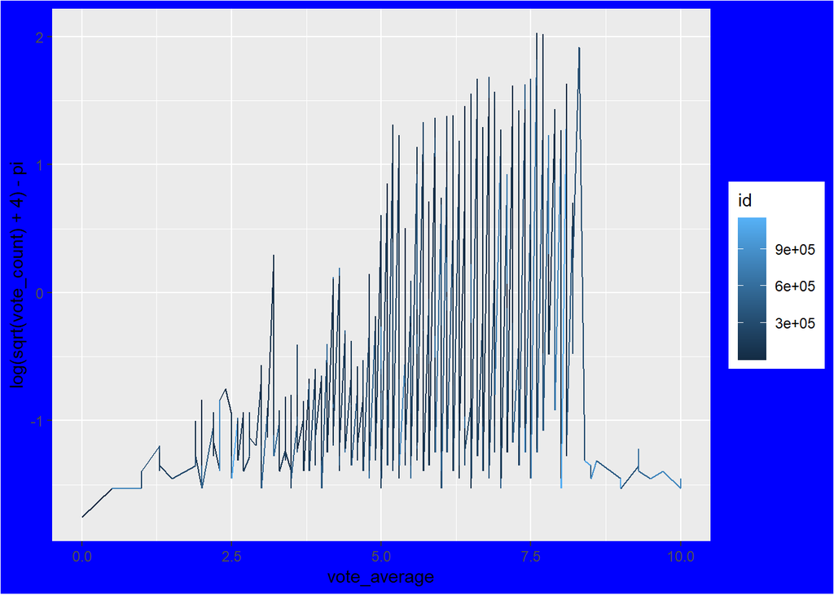

```r
ggplot(aliens_sf, aes(vote_average, log(sqrt(vote_count)+4)-pi, col=id)) + geom_line() + theme(plot.background = element_rect(fill="blue"))
```

THIS IS VERY UGLY INDEED